# linc-Brn1b KO vs WT (Embryonic)

## Differential Splicing

### Differential Isoforms between conditions

Per isoform difference between conditions:

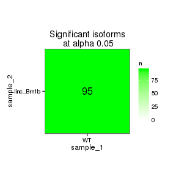

These isoforms are:

|  | isoAnnot$gene_short_name |
| --- | --- |
| 1 | Nfix |
| 2 | Grik3 |
| 3 | Rec8 |
| 4 | Crabp2 |
| 5 | Ndrg1 |
| 6 | Mef2c |
| 7 | Phox2b |
| 8 | Hivep2 |
| 9 | Celsr1 |
| 10 | Lhx1 |
| 11 | Kitl |
| 12 | Foxg1 |
| 13 | Fezf2 |
| 14 | Sla |
| 15 | Sncg |
| 16 | Dlx2 |
| 17 | Prph |
| 18 | Tiam2 |
| 19 | Lbx1 |
| 20 | Nnt |
| 21 | Lancl1 |
| 22 | Ngef |
| 23 | Asb1 |
| 24 | Lypd1 |
| 25 | Lhx6 |
| 26 | Syt13 |
| 27 | Ntsr1 |
| 28 | Tal2 |
| 29 | Fosl2 |
| 30 | Nos1 |

[output cut: 64 more lines]

Gene-level DE isoform heatmap

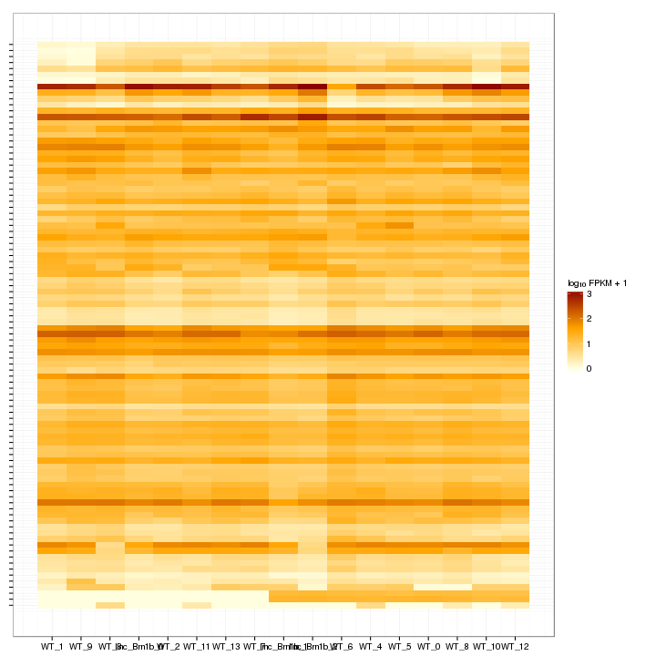

Isoform foldchange heatmap by isoform:

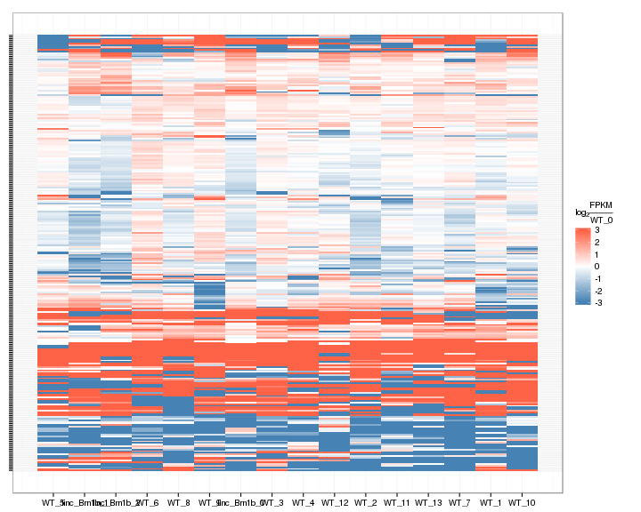

### Differential Splicing between conditions

(eval false for first pass)

# Gene/Pathway Analysis

## GSEA

Enrichment and zscores are calculated based on expression in KO vs WT (fpkmKO/fpkmWT), so genes that are down regulated in KO are shown in blue, while upregulation is shown in red.

KO/WT Blue = down in KO Red = Up in KO

Biocarta enrichment:

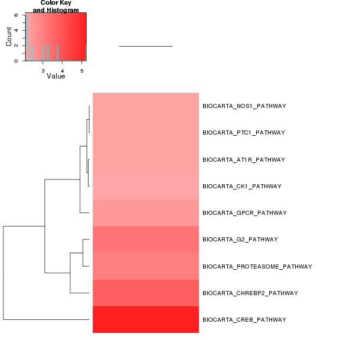

Biocarta zscore:

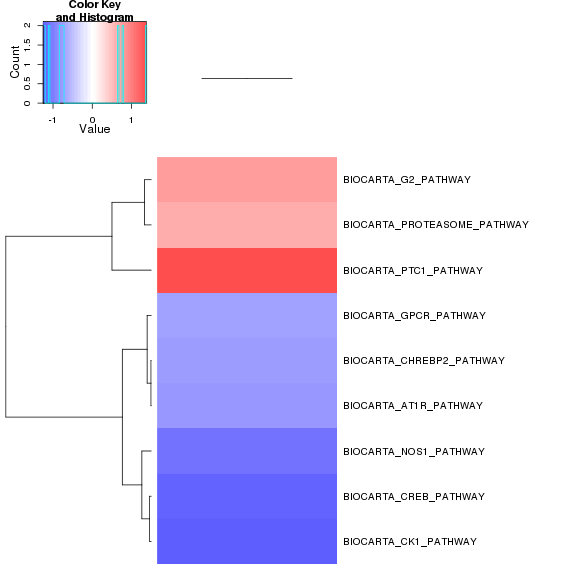

Reactome enrichment:

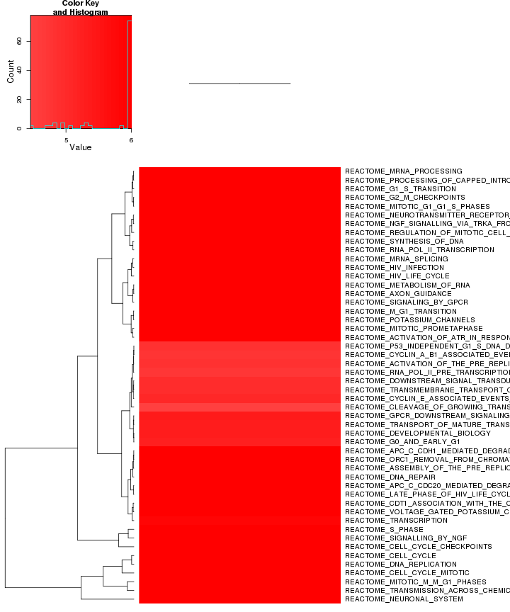

Reactome zscore:

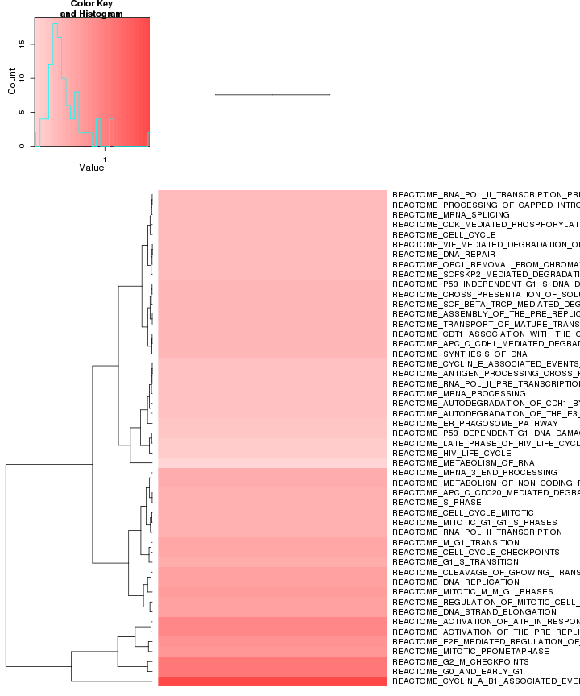

Kegg enrichment:

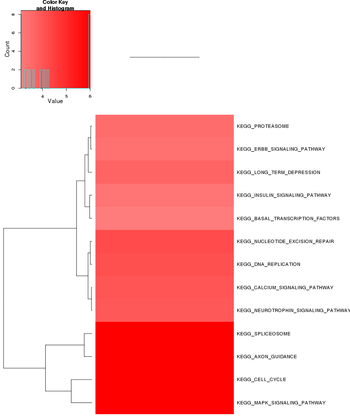

Kegg zscore:

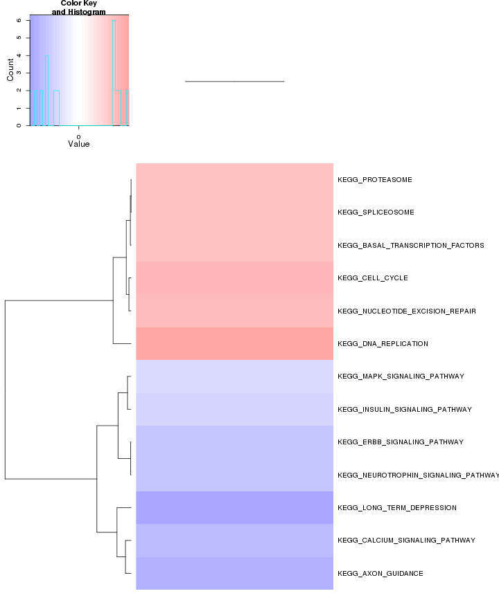

Interneuron enrichment:

[output not shown]

Interneuron zscore:

[output not shown]

[output not shown]

[output not shown]

[output not shown]

Oncogene enrichment:

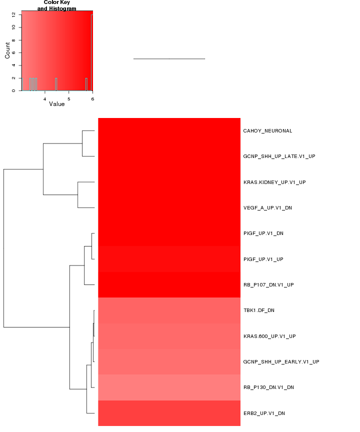

Oncogene zscore:

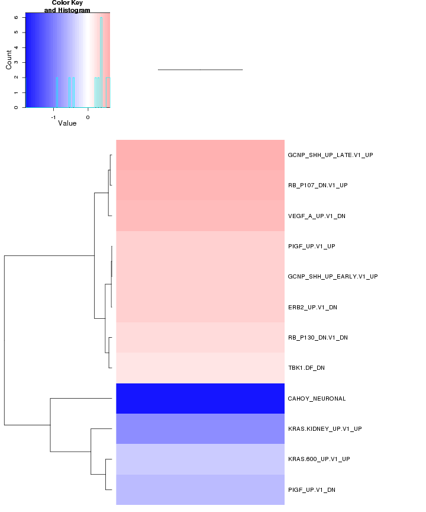

Immuno enrichment:

[output not shown]

[figure not shown]

Immuno zscore:

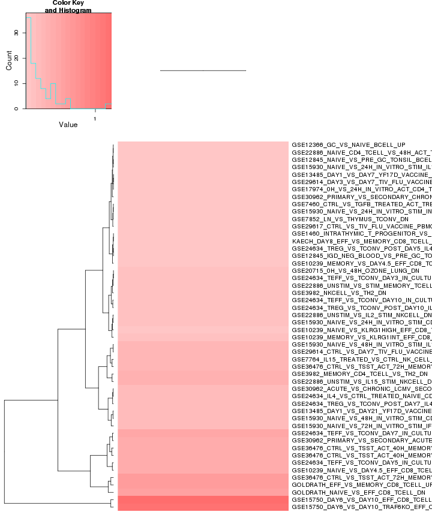

TF enrichment:

[output not shown]

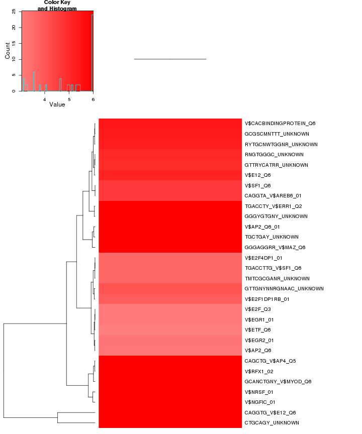

TF zscore:

[output not shown]

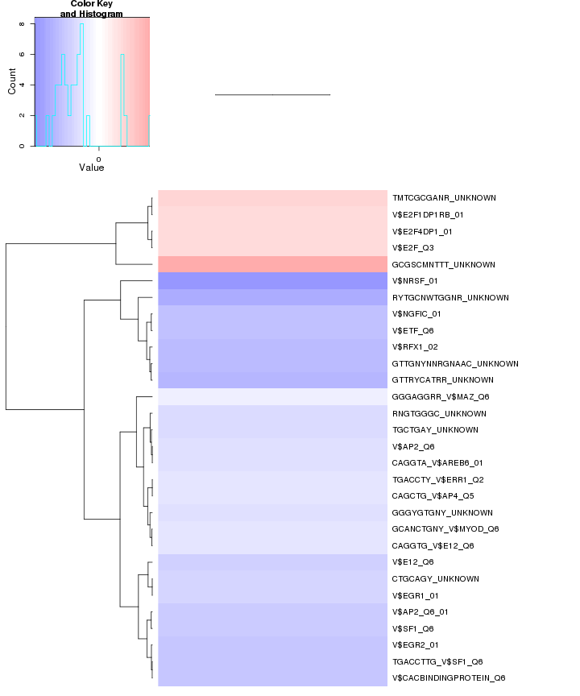

## GO enrichment

Cluster profiler used to call enichments of significantly differentially regulated genes that map to Entrez IDs.

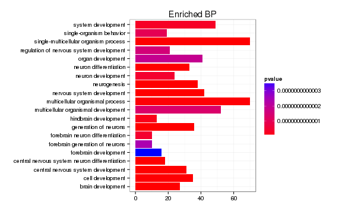

[figure not shown]

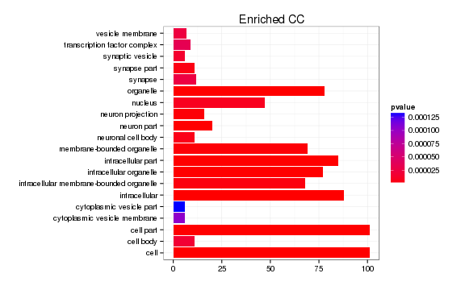

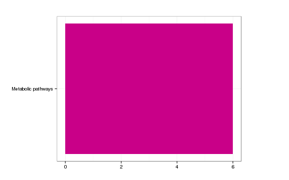

[output not shown]

### Enrichment or depletion for stage-specific cell cycle markers

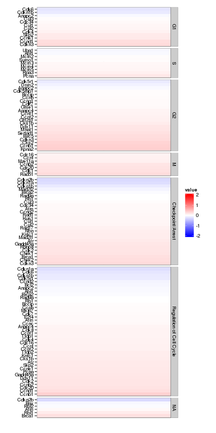

### Enrichment or depletion for markers of specific cortical layers

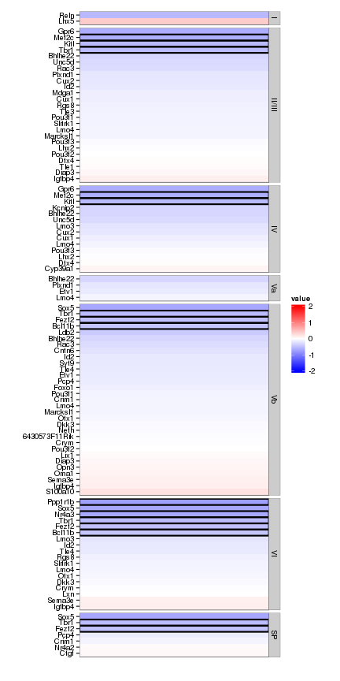

### Enrichment or depletion for specific neural cell types

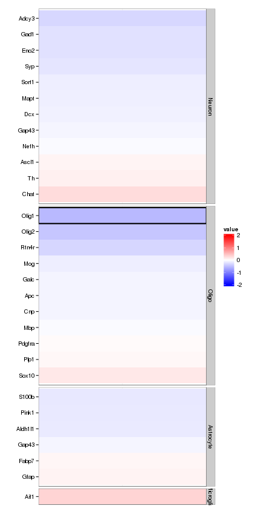

### Enrichment or Depletion of neural differentiation markers

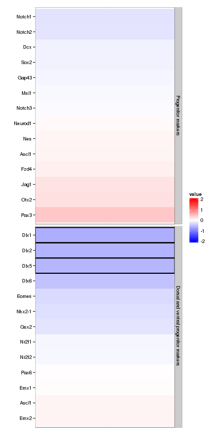

# Cis vs Trans (locally)

log2 Foldchange and test statistic are calculated with the ratio of fpkm(KO)/fpkm(WT), thus the test_stat is positive if a gene is higher in the KO and negative if a gene has lower expression in the KO

The pvalue for 0 genes significantly regulated in a region this size is: 1

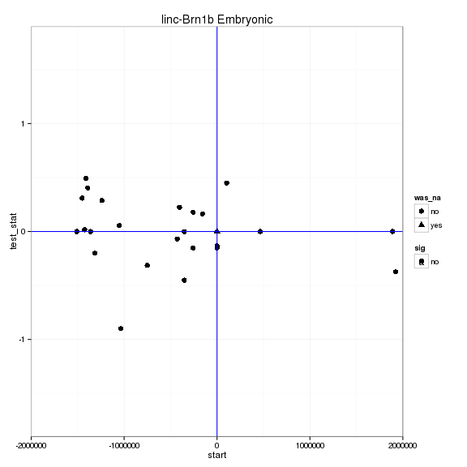

# Notes

## Samples used are:

|  | 10 |
| --- | --- |
| 1 | JR753 |
| 2 | JR750 |
| 3 | JR771 |
| 4 | JR755 |
| 5 | JR811 |
| 6 | JR768 |
| 7 | JR761 |
| 8 | JR815 |
| 9 | JR789 |
| 10 | JR748 |
| 11 | JR716 |
| 12 | JR717 |
| 13 | JR719 |
| 14 | JR756 |
| 15 | JR758 |
| 16 | JR764 |
| 17 | JR808 |

## Replicates

|  | file | sample_name | replicate | rep_name | total_mass | norm_mass | internal_scale | external_scale |
| --- | --- | --- | --- | --- | --- | --- | --- | --- |
| 1 | /n/rinn_data1/seq/lgoff/Projects/BrainMap/data/quants/JR753/abundances.cxb | WT | 0 | WT_0 | 39331900.00 | 32398700.00 | 1.25 | 1.00 |
| 2 | /n/rinn_data1/seq/lgoff/Projects/BrainMap/data/quants/JR750/abundances.cxb | WT | 1 | WT_1 | 36031100.00 | 32398700.00 | 1.09 | 1.00 |
| 3 | /n/rinn_data1/seq/lgoff/Projects/BrainMap/data/quants/JR771/abundances.cxb | WT | 2 | WT_2 | 38857100.00 | 32398700.00 | 1.22 | 1.00 |
| 4 | /n/rinn_data1/seq/lgoff/Projects/BrainMap/data/quants/JR755/abundances.cxb | WT | 3 | WT_3 | 41811300.00 | 32398700.00 | 1.28 | 1.00 |
| 5 | /n/rinn_data1/seq/lgoff/Projects/BrainMap/data/quants/JR811/abundances.cxb | WT | 4 | WT_4 | 38172800.00 | 32398700.00 | 1.19 | 1.00 |
| 6 | /n/rinn_data1/seq/lgoff/Projects/BrainMap/data/quants/JR768/abundances.cxb | WT | 5 | WT_5 | 28375200.00 | 32398700.00 | 0.89 | 1.00 |
| 7 | /n/rinn_data1/seq/lgoff/Projects/BrainMap/data/quants/JR761/abundances.cxb | WT | 6 | WT_6 | 31706200.00 | 32398700.00 | 0.97 | 1.00 |
| 8 | /n/rinn_data1/seq/lgoff/Projects/BrainMap/data/quants/JR815/abundances.cxb | WT | 7 | WT_7 | 29733100.00 | 32398700.00 | 0.91 | 1.00 |
| 9 | /n/rinn_data1/seq/lgoff/Projects/BrainMap/data/quants/JR789/abundances.cxb | WT | 8 | WT_8 | 27681500.00 | 32398700.00 | 0.85 | 1.00 |
| 10 | /n/rinn_data1/seq/lgoff/Projects/BrainMap/data/quants/JR748/abundances.cxb | WT | 9 | WT_9 | 32367000.00 | 32398700.00 | 0.95 | 1.00 |
| 11 | /n/rinn_data1/seq/lgoff/Projects/BrainMap/data/quants/JR716/abundances.cxb | WT | 10 | WT_10 | 26144700.00 | 32398700.00 | 0.80 | 1.00 |
| 12 | /n/rinn_data1/seq/lgoff/Projects/BrainMap/data/quants/JR717/abundances.cxb | WT | 11 | WT_11 | 25565400.00 | 32398700.00 | 0.79 | 1.00 |
| 13 | /n/rinn_data1/seq/lgoff/Projects/BrainMap/data/quants/JR719/abundances.cxb | WT | 12 | WT_12 | 22697800.00 | 32398700.00 | 0.68 | 1.00 |
| 14 | /n/rinn_data1/seq/lgoff/Projects/BrainMap/data/quants/JR756/abundances.cxb | WT | 13 | WT_13 | 38948900.00 | 32398700.00 | 1.20 | 1.00 |
| 15 | /n/rinn_data1/seq/lgoff/Projects/BrainMap/data/quants/JR758/abundances.cxb | linc_Brn1b | 0 | linc_Brn1b_0 | 41595700.00 | 32398700.00 | 1.31 | 1.00 |
| 16 | /n/rinn_data1/seq/lgoff/Projects/BrainMap/data/quants/JR764/abundances.cxb | linc_Brn1b | 1 | linc_Brn1b_1 | 30294500.00 | 32398700.00 | 0.95 | 1.00 |
| 17 | /n/rinn_data1/seq/lgoff/Projects/BrainMap/data/quants/JR808/abundances.cxb | linc_Brn1b | 2 | linc_Brn1b_2 | 31223700.00 | 32398700.00 | 0.97 | 1.00 |

## Run Info

[output not shown]